# TradeComps: Trade Competitiveness & Investment Attractiveness in Sub-Saharan Africa

Author

Ludovic Njiosseu, MS Biostatistics

Published

May 19, 2026

## Overview

This project analyzes trade competitiveness and foreign direct investment dynamics for 12 Sub-Saharan African economies across the EAC, ECOWAS, and SADC regional blocs, covering 2015–2023. It is motivated by the implementation of the African Continental Free Trade Area (AfCFTA) and the question of which economies are best positioned to benefit.

**Data sources simulated from:** World Bank WDI, ITC Trade Map, UNCTAD bilateral FDI statistics.

## Module 1 — Data Construction

```r
source("scripts/01_simulate_data.R")
```

```
Trade panel: 108 rows × 13 columns
Countries: 12 | Years: 2015–2023
Saved: data/trade_panel.csv
```

```r
library(tidyverse)
```

The panel dataset covers 12 economies × 9 years (108 observations). Key variables: Revealed Comparative Advantage (RCA), export concentration (HHI), FDI inflows, regulatory environment, infrastructure index, trade openness, and AfCFTA readiness.

## Module 2 — Export Competitiveness Index

```r
source("scripts/02_competitiveness_index.R")
```

```
--- RCA Ranking (Latest Year) ---
# A tibble: 12 × 6
   country       iso3  region   rca hhi_export export_value_bn
   <chr>         <chr> <chr>  <dbl>      <dbl>           <dbl>
 1 Nigeria       NGA   ECOWAS  2.33      0.641          116.
 2 South Africa  ZAF   SADC    1.96      0.373           84.0
 3 Cameroon      CMR   ECOWAS  1.70      0.479           10.8
 4 Côte d'Ivoire CIV   ECOWAS  1.64      0.483           15.2
 5 Ethiopia      ETH   EAC     1.63      0.558           39.3
 6 Ghana         GHA   ECOWAS  1.55      0.499           17.0
 7 Kenya         KEN   EAC     1.40      0.397           27.8
 8 Uganda        UGA   EAC     1.34      0.501           11.6
 9 Senegal       SEN   ECOWAS  1.34      0.467            6.18
10 Mozambique    MOZ   SADC    1.34      0.607            3.81
11 Tanzania      TZA   EAC     1.27      0.472           18.3
12 Rwanda        RWA   EAC     1.05      0.5              2.96

--- Composite Export Competitiveness Index ---
# A tibble: 12 × 7
   country       region   rca cagr_pct avg_diversification competitiveness_score
   <chr>         <chr>  <dbl>    <dbl>               <dbl>                 <dbl>
 1 Nigeria       ECOWAS  2.33     3.25               0.341                 0.676
 2 Kenya         EAC     1.40     4.74               0.654                 0.587
 3 Ethiopia      EAC     1.63     4.02               0.505                 0.562
 4 South Africa  SADC    1.96     1.82               0.658                 0.550
 5 Senegal       ECOWAS  1.34     4.98               0.504                 0.543
 6 Cameroon      ECOWAS  1.70     3.21               0.514                 0.529
 7 Côte d'Ivoire ECOWAS  1.64     2.51               0.512                 0.458
 8 Uganda        EAC     1.34     3.16               0.502                 0.410
 9 Ghana         ECOWAS  1.55     1.55               0.509                 0.359
10 Tanzania      EAC     1.27     2.71               0.499                 0.353
11 Mozambique    SADC    1.34     1.81               0.365                 0.268
12 Rwanda        EAC     1.05     0.88               0.495                 0.148
# ℹ 1 more variable: competitiveness_rank <int>

--- Value Chain Quadrant Analysis ---
# A tibble: 12 × 6
   country       region   rca hhi_export quadrant          competitiveness_score
   <chr>         <chr>  <dbl>      <dbl> <chr>                             <dbl>
 1 Nigeria       ECOWAS  2.33      0.641 Competitive but …                 0.676
 2 Kenya         EAC     1.40      0.397 Diversified but …                 0.587
 3 Ethiopia      EAC     1.63      0.558 Competitive but …                 0.562
 4 South Africa  SADC    1.96      0.373 Competitive & Di…                 0.550
 5 Senegal       ECOWAS  1.34      0.467 Diversified but …                 0.543
 6 Cameroon      ECOWAS  1.70      0.479 Competitive & Di…                 0.529
 7 Côte d'Ivoire ECOWAS  1.64      0.483 Competitive & Di…                 0.458
 8 Uganda        EAC     1.34      0.501 Concentrated & W…                 0.410
 9 Ghana         ECOWAS  1.55      0.499 Competitive but …                 0.359
10 Tanzania      EAC     1.27      0.472 Diversified but …                 0.353
11 Mozambique    SADC    1.34      0.607 Concentrated & W…                 0.268
12 Rwanda        EAC     1.05      0.5   Concentrated & W…                 0.148

Competitiveness index complete.
```

### RCA Rankings

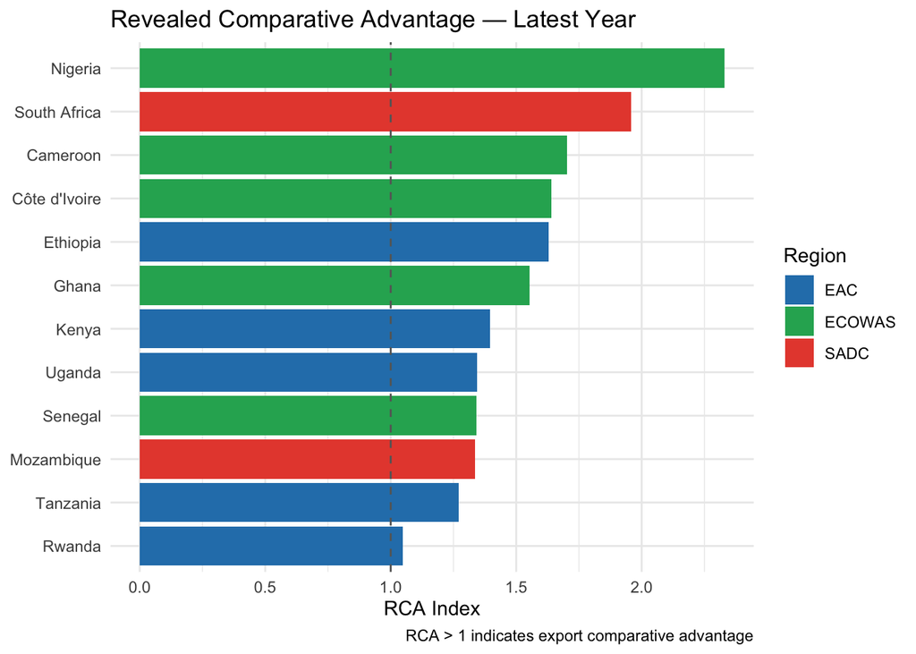

```r
rca_latest <- read_csv("outputs/rca_ranking_latest.csv", show_col_types = FALSE)
rca_latest %>%
  mutate(country = fct_reorder(country, rca)) %>%
  ggplot(aes(x = country, y = rca, fill = region)) +
  geom_col() + coord_flip() +
  geom_hline(yintercept = 1, linetype = "dashed", color = "grey40") +
  scale_fill_manual(values = c(EAC = "#2980b9", ECOWAS = "#27ae60", SADC = "#e74c3c")) +
  labs(title = "Revealed Comparative Advantage — Latest Year",
       x = NULL, y = "RCA Index", fill = "Region",
       caption = "RCA > 1 indicates export comparative advantage") +
  theme_minimal()
```

### Composite Export Competitiveness Index

```r
comp_idx <- read_csv("outputs/competitiveness_index.csv", show_col_types = FALSE)
comp_idx %>%
  select(country, region, rca, cagr_pct, avg_diversification,
         competitiveness_score, competitiveness_rank) %>%
  knitr::kable(caption = "Composite Export Competitiveness Index")
```

Composite Export Competitiveness Index

| country | region | rca | cagr_pct | avg_diversification | competitiveness_score | competitiveness_rank |
| --- | --- | --- | --- | --- | --- | --- |
| Nigeria | ECOWAS | 2.330 | 3.25 | 0.341 | 0.6757 | 1 |
| Kenya | EAC | 1.396 | 4.74 | 0.654 | 0.5870 | 2 |
| Ethiopia | EAC | 1.629 | 4.02 | 0.505 | 0.5624 | 3 |
| South Africa | SADC | 1.959 | 1.82 | 0.658 | 0.5503 | 4 |
| Senegal | ECOWAS | 1.342 | 4.98 | 0.504 | 0.5427 | 5 |
| Cameroon | ECOWAS | 1.702 | 3.21 | 0.514 | 0.5286 | 6 |
| Côte d’Ivoire | ECOWAS | 1.641 | 2.51 | 0.512 | 0.4577 | 7 |
| Uganda | EAC | 1.345 | 3.16 | 0.502 | 0.4099 | 8 |
| Ghana | ECOWAS | 1.554 | 1.55 | 0.509 | 0.3594 | 9 |
| Tanzania | EAC | 1.270 | 2.71 | 0.499 | 0.3526 | 10 |
| Mozambique | SADC | 1.337 | 1.81 | 0.365 | 0.2675 | 11 |
| Rwanda | EAC | 1.049 | 0.88 | 0.495 | 0.1485 | 12 |

The index is weighted: RCA (40%), export CAGR 2015–2023 (30%), export diversification / 1−HHI (30%).

### Value Chain Quadrant Analysis

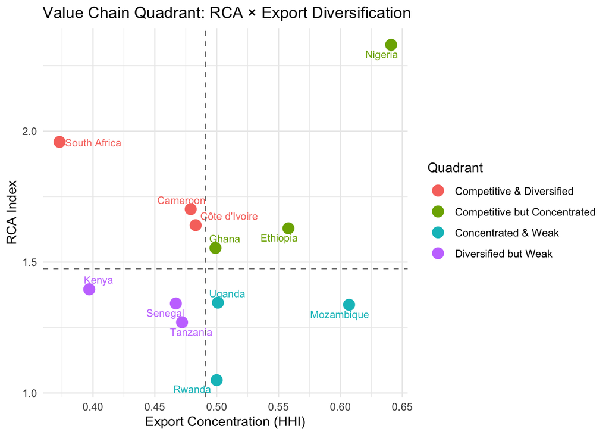

```r
quadrant <- read_csv("outputs/quadrant_analysis.csv", show_col_types = FALSE)
quadrant %>%
  ggplot(aes(x = hhi_export, y = rca, color = quadrant, label = country)) +
  geom_point(size = 4) +
  ggrepel::geom_text_repel(size = 3, max.overlaps = 15) +
  geom_vline(xintercept = median(quadrant$hhi_export), linetype = "dashed", color = "grey50") +
  geom_hline(yintercept = median(quadrant$rca),        linetype = "dashed", color = "grey50") +
  labs(title = "Value Chain Quadrant: RCA × Export Diversification",
       x = "Export Concentration (HHI)", y = "RCA Index", color = "Quadrant") +
  theme_minimal()
```

## Module 3 — FDI & Investment Attractiveness

```r
source("scripts/03_fdi_analysis.R")
```

```
--- Aggregate FDI Trend ---
# A tibble: 9 × 4
   year total_fdi_bn avg_fdi_bn fdi_growth_yoy
  <dbl>        <dbl>      <dbl>          <dbl>
1  2015         22.3       1.86          NA
2  2016         25.9       2.16          16.1
3  2017         27.2       2.27           4.81
4  2018         26.9       2.24          -0.92
5  2019         26.4       2.20          -2.2
6  2020         20.0       1.67         -24.1
7  2021         29.3       2.44          46.6
8  2022         28.8       2.40          -1.91
9  2023         29.4       2.45           2.3

--- FDI by Country ---
# A tibble: 12 × 10
   country       iso3  region avg_fdi_bn fdi_2015 fdi_2019 fdi_2020 fdi_2023
   <chr>         <chr> <chr>       <dbl>    <dbl>    <dbl>    <dbl>    <dbl>
 1 Nigeria       NGA   ECOWAS      5.38     4.59     5.55     4.76     5.73
 2 South Africa  ZAF   SADC        5.36     4.34     4.46     3.80     6.16
 3 Ethiopia      ETH   EAC         3.64     2.99     4.27     1.91     4.57
 4 Ghana         GHA   ECOWAS      3.07     2.45     3.75     2.26     3.03
 5 Mozambique    MOZ   SADC        2.73     2.53     2.19     2.56     2.77
 6 Kenya         KEN   EAC         1.28     1.05     1.36     0.976    1.51
 7 Tanzania      TZA   EAC         1.07     0.883    1.06     1.08     1.34
 8 Côte d'Ivoire CIV   ECOWAS      0.975    0.921    0.868    0.661    1.28
 9 Uganda        UGA   EAC         0.805    0.638    0.858    0.611    0.868
10 Cameroon      CMR   ECOWAS      0.794    0.89     0.724    0.588    0.843
11 Senegal       SEN   ECOWAS      0.686    0.64     0.816    0.432    0.74
12 Rwanda        RWA   EAC         0.472    0.436    0.446    0.37     0.594
# ℹ 2 more variables: covid_impact_pct <dbl>, cagr_2015_2023 <dbl>

--- Investment Attractiveness Ranking ---
# A tibble: 12 × 9
   country       iso3  region regulatory_env infrastructure trade_openness
   <chr>         <chr> <chr>           <dbl>          <dbl>          <dbl>
 1 South Africa  ZAF   SADC             7.53           7.94          0.502
 2 Kenya         KEN   EAC              7.1            6.34          0.724
 3 Rwanda        RWA   EAC              8.23           6.62          0.406
 4 Ghana         GHA   ECOWAS           6.75           6.14          0.479
```

[output cut: 14 more lines]

```
   <chr>         <chr> <chr>                 <dbl>       <dbl>
 1 Rwanda        RWA   EAC                    6.97        7.81
 2 Ghana         GHA   ECOWAS                 6.88        7.74
 3 Kenya         KEN   EAC                    7.04        7.5
 4 South Africa  ZAF   SADC                   6.66        6.72
 5 Côte d'Ivoire CIV   ECOWAS                 5.44        6.32
 6 Tanzania      TZA   EAC                    5.3         5.93
 7 Mozambique    MOZ   SADC                   5.26        5.8
 8 Uganda        UGA   EAC                    5.53        5.79
 9 Senegal       SEN   ECOWAS                 5.1         5.64
10 Cameroon      CMR   ECOWAS                 5.15        5.44
11 Ethiopia      ETH   EAC                    4.46        5.21
12 Nigeria       NGA   ECOWAS                 4.4         4.77

FDI analysis complete.
```

### FDI Trends by Region

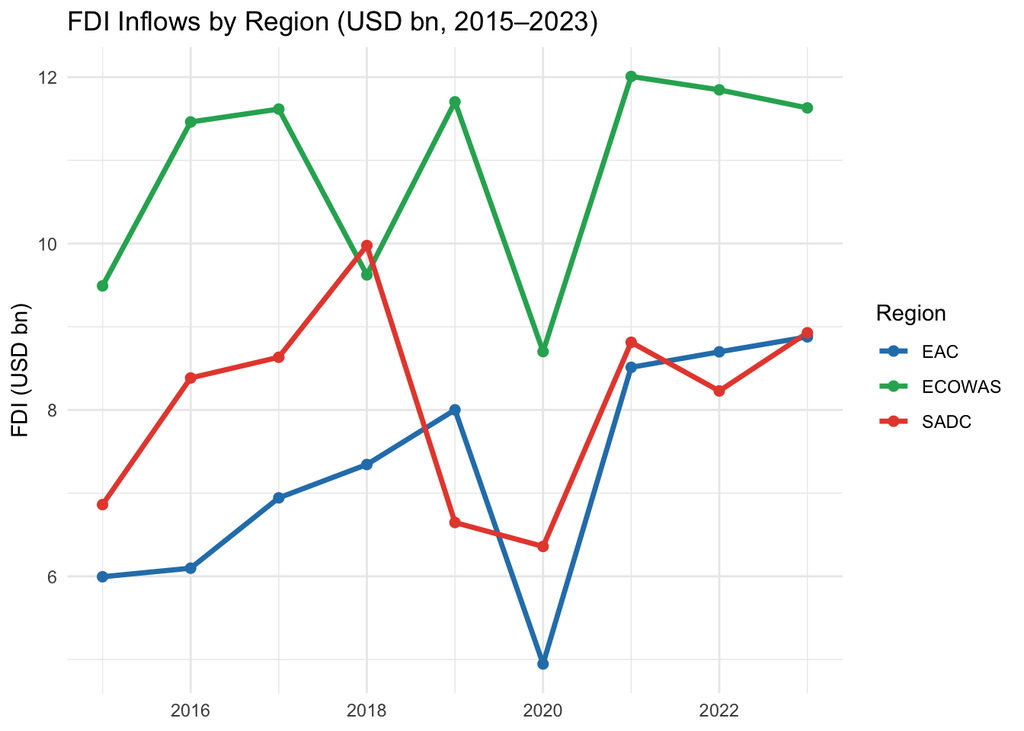

```r
fdi_region <- read_csv("outputs/fdi_by_region.csv", show_col_types = FALSE)
fdi_region %>%
  ggplot(aes(x = year, y = regional_fdi_bn, color = region, group = region)) +
  geom_line(size = 1.2) + geom_point(size = 2) +
  scale_color_manual(values = c(EAC = "#2980b9", ECOWAS = "#27ae60", SADC = "#e74c3c")) +
  labs(title = "FDI Inflows by Region (USD bn, 2015–2023)",
       x = NULL, y = "FDI (USD bn)", color = "Region") +
  theme_minimal()
```

The 2020 COVID shock is visible across all regions, with differential recovery trajectories.

### Investment Attractiveness Ranking

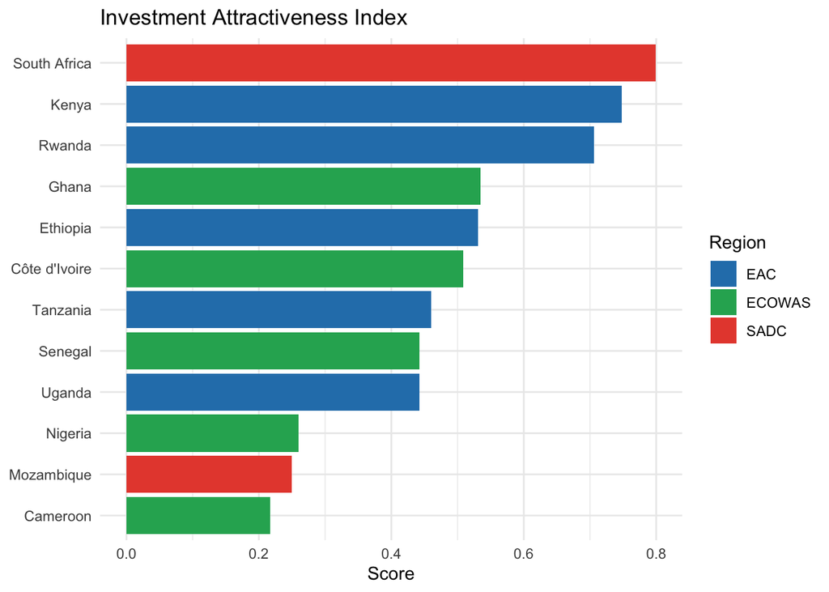

```r
attract <- read_csv("outputs/investment_attractiveness.csv", show_col_types = FALSE)
attract %>%
  mutate(country = fct_reorder(country, attractiveness_score)) %>%
  ggplot(aes(x = country, y = attractiveness_score, fill = region)) +
  geom_col() + coord_flip() +
  scale_fill_manual(values = c(EAC = "#2980b9", ECOWAS = "#27ae60", SADC = "#e74c3c")) +
  labs(title = "Investment Attractiveness Index",
       x = NULL, y = "Score", fill = "Region") +
  theme_minimal()
```

### FDI Determinants

```r
fdi_det <- read_csv("outputs/fdi_determinants.csv", show_col_types = FALSE)
knitr::kable(fdi_det, caption = "OLS Regression: Determinants of FDI Inflows (log)")
```

OLS Regression: Determinants of FDI Inflows (log)

| variable | coefficient | std_error | t_value | p_value |
| --- | --- | --- | --- | --- |
| (Intercept) | -1.3288 | 0.7903 | -1.681 | 0.0985 |
| regulatory_env | -0.4539 | 0.1932 | -2.349 | 0.0225 |
| infrastructure | 0.2121 | 0.1781 | 1.191 | 0.2390 |
| trade_openness | 0.3969 | 0.6625 | 0.599 | 0.5516 |
| afcfta_readiness | 0.2657 | 0.1425 | 1.865 | 0.0676 |
| rca | 1.0773 | 0.3353 | 3.212 | 0.0022 |

## Module 4 — Regional Policy Analysis

```r
source("scripts/04_regional_policy.R")
```

```
--- Regional Summary ---
# A tibble: 3 × 10
  region n_countries avg_rca avg_hhi avg_diversification total_fdi_bn avg_fdi_bn
  <chr>        <int>   <dbl>   <dbl>               <dbl>        <dbl>      <dbl>
1 EAC              5    1.34   0.486               0.514         8.88       1.78
2 ECOWAS           5    1.71   0.514               0.486        11.6        2.33
3 SADC             2    1.65   0.49                0.51          8.93       4.46
# ℹ 3 more variables: avg_regulatory <dbl>, avg_infrastructure <dbl>,
#   avg_trade_openness <dbl>

--- Combined Competitiveness + Attractiveness Ranking ---
# A tibble: 12 × 9
   country       iso3  region competitiveness_score competitiveness_rank
   <chr>         <chr> <chr>                  <dbl>                <dbl>
 1 South Africa  ZAF   SADC                   0.550                    4
 2 Kenya         KEN   EAC                    0.587                    2
 3 Ethiopia      ETH   EAC                    0.562                    3
 4 Senegal       SEN   ECOWAS                 0.543                    5
 5 Côte d'Ivoire CIV   ECOWAS                 0.458                    7
 6 Nigeria       NGA   ECOWAS                 0.676                    1
 7 Ghana         GHA   ECOWAS                 0.359                    9
 8 Rwanda        RWA   EAC                    0.148                   12
 9 Uganda        UGA   EAC                    0.410                    8
10 Tanzania      TZA   EAC                    0.353                   10
11 Cameroon      CMR   ECOWAS                 0.529                    6
12 Mozambique    MOZ   SADC                   0.268                   11
# ℹ 4 more variables: attractiveness_score <dbl>, attractiveness_rank <dbl>,
#   combined_score <dbl>, combined_rank <int>

--- AfCFTA Sector Priority & Policy Recommendation ---
# A tibble: 12 × 4
   country       region quadrant                     priority_sector
   <chr>         <chr>  <chr>                        <chr>
 1 Kenya         EAC    Diversified but Weak         Agri-food / Light manufact…
 2 Ethiopia      EAC    Competitive but Concentrated Extractives value-addition…
 3 Uganda        EAC    Concentrated & Weak          FDI attraction / Infrastru…
 4 Tanzania      EAC    Diversified but Weak         Agri-food / Light manufact…
 5 Rwanda        EAC    Concentrated & Weak          FDI attraction / Infrastru…
 6 Nigeria       ECOWAS Competitive but Concentrated Extractives value-addition…
 7 Senegal       ECOWAS Diversified but Weak         Agri-food / Light manufact…
 8 Cameroon      ECOWAS Competitive & Diversified    Manufactured goods / Digit…
 9 Côte d'Ivoire ECOWAS Competitive & Diversified    Manufactured goods / Digit…
10 Ghana         ECOWAS Competitive but Concentrated Extractives value-addition…
11 South Africa  SADC   Competitive & Diversified    Manufactured goods / Digit…
12 Mozambique    SADC   Concentrated & Weak          FDI attraction / Infrastru…

--- FDI Determinants (R² = 0.511) ---
# A tibble: 6 × 5
  variable         coefficient std_error t_value p_value
  <chr>                  <dbl>     <dbl>   <dbl>   <dbl>
1 (Intercept)           -1.33      0.790  -1.68   0.0985
2 regulatory_env        -0.454     0.193  -2.35   0.0225
3 infrastructure         0.212     0.178   1.19   0.239
4 trade_openness         0.397     0.662   0.599  0.552
5 afcfta_readiness       0.266     0.142   1.86   0.0676
6 rca                    1.08      0.335   3.21   0.0022
Adjusted R²: 0.4655

Regional analysis and policy data complete.
```

### Regional Comparison

```r
regional <- read_csv("outputs/regional_summary.csv", show_col_types = FALSE)
knitr::kable(regional, caption = "EAC vs ECOWAS vs SADC — Aggregate Indicators")
```

EAC vs ECOWAS vs SADC — Aggregate Indicators

| region | n_countries | avg_rca | avg_hhi | avg_diversification | total_fdi_bn | avg_fdi_bn | avg_regulatory | avg_infrastructure | avg_trade_openness |
| --- | --- | --- | --- | --- | --- | --- | --- | --- | --- |
| EAC | 5 | 1.338 | 0.486 | 0.514 | 8.88 | 1.78 | 6.47 | 5.45 | 0.565 |
| ECOWAS | 5 | 1.714 | 0.514 | 0.486 | 11.63 | 2.33 | 5.64 | 5.39 | 0.527 |
| SADC | 2 | 1.648 | 0.490 | 0.510 | 8.93 | 4.46 | 6.19 | 6.10 | 0.564 |

### AfCFTA Readiness

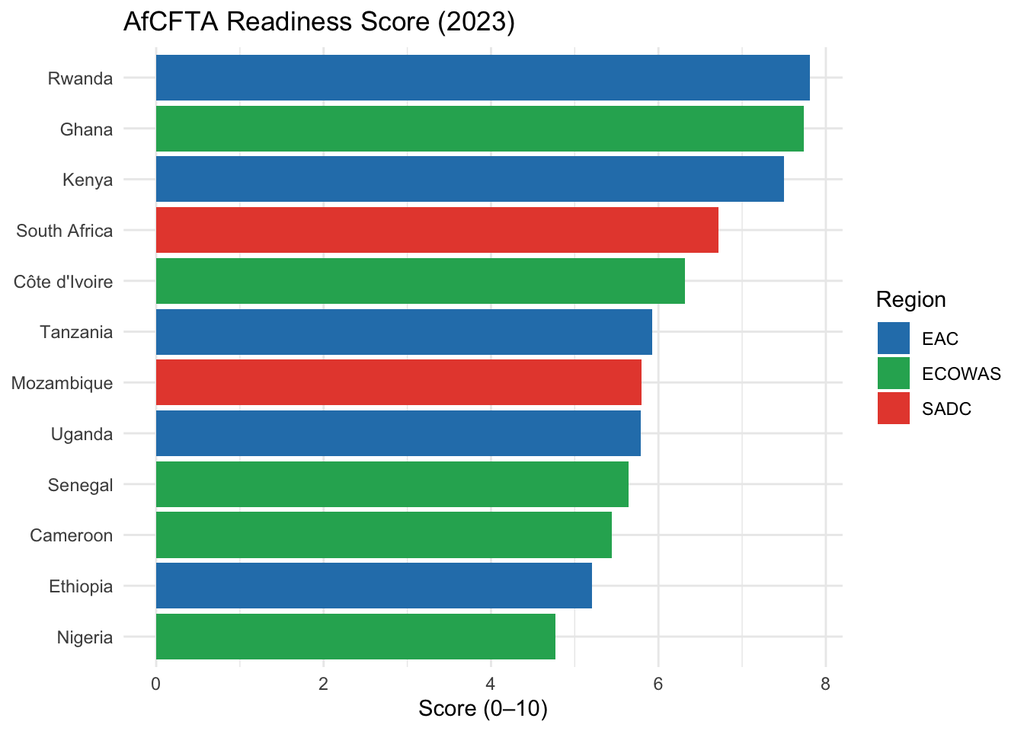

```r
afcfta <- read_csv("outputs/afcfta_readiness.csv", show_col_types = FALSE)
afcfta %>%
  mutate(country = fct_reorder(country, afcfta_2023)) %>%
  ggplot(aes(x = country, y = afcfta_2023, fill = region)) +
  geom_col() + coord_flip() +
  scale_fill_manual(values = c(EAC = "#2980b9", ECOWAS = "#27ae60", SADC = "#e74c3c")) +
  labs(title = "AfCFTA Readiness Score (2023)",
       x = NULL, y = "Score (0–10)", fill = "Region") +
  theme_minimal()
```

### Sector Priority & Policy Recommendations

```r
sector_prior <- read_csv("outputs/sector_priority.csv", show_col_types = FALSE)
sector_prior %>%
  select(country, region, quadrant, priority_sector, policy_recommendation) %>%
  knitr::kable(caption = "Sector Priority and Policy Recommendations by Country")
```

Sector Priority and Policy Recommendations by Country

| country | region | quadrant | priority_sector | policy_recommendation |
| --- | --- | --- | --- | --- |
| Kenya | EAC | Diversified but Weak | Agri-food / Light manufacturing | Strengthen RCA through sectoral industrial policy and export promotion |
| Ethiopia | EAC | Competitive but Concentrated | Extractives value-addition / Agri-processing | Diversify export basket; develop processing zones to capture value-add |
| Uganda | EAC | Concentrated & Weak | FDI attraction / Infrastructure-first | Prioritize regulatory reform and infrastructure to attract FDI inflows |
| Tanzania | EAC | Diversified but Weak | Agri-food / Light manufacturing | Strengthen RCA through sectoral industrial policy and export promotion |
| Rwanda | EAC | Concentrated & Weak | FDI attraction / Infrastructure-first | Prioritize regulatory reform and infrastructure to attract FDI inflows |
| Nigeria | ECOWAS | Competitive but Concentrated | Extractives value-addition / Agri-processing | Diversify export basket; develop processing zones to capture value-add |
| Senegal | ECOWAS | Diversified but Weak | Agri-food / Light manufacturing | Strengthen RCA through sectoral industrial policy and export promotion |
| Cameroon | ECOWAS | Competitive & Diversified | Manufactured goods / Digital services | Deepen AfCFTA trade facilitation; invest in digital trade infrastructure |
| Côte d’Ivoire | ECOWAS | Competitive & Diversified | Manufactured goods / Digital services | Deepen AfCFTA trade facilitation; invest in digital trade infrastructure |
| Ghana | ECOWAS | Competitive but Concentrated | Extractives value-addition / Agri-processing | Diversify export basket; develop processing zones to capture value-add |
| South Africa | SADC | Competitive & Diversified | Manufactured goods / Digital services | Deepen AfCFTA trade facilitation; invest in digital trade infrastructure |
| Mozambique | SADC | Concentrated & Weak | FDI attraction / Infrastructure-first | Prioritize regulatory reform and infrastructure to attract FDI inflows |

## Reproducibility

```r
install.packages(c("tidyverse", "ggrepel", "shiny", "bslib", "bsicons"))

source("scripts/01_simulate_data.R")
source("scripts/02_competitiveness_index.R")
source("scripts/03_fdi_analysis.R")
source("scripts/04_regional_policy.R")

shiny::runApp("shiny/")
quarto::quarto_render("tradecomps_report.qmd")
```

## Limitations & Extensions

- Data is simulated to approximate published WDI/UNCTAD patterns; actual analysis would use API-pulled panel data.
- The RCA index is simplified — production analysis would compute bilateral RCA across product-level HS codes.
- Panel regression with country and year fixed effects would better isolate causal FDI determinants.
- Value chain depth (processing stage, GVC participation) is not modeled; this is the key gap for AfCFTA sector analysis.